| title: “LAB 10” |
| --- |
| author: “JESSICA PAOLA AGUILAR SERVIN” |
| date: “2023-02-23” |
| output: html_document |

T1_04_REDES COMPLEJAS(1) - Visión de redes complejas - parte 1

Objetivo: Estimar el Maximum Spanning Tree -árbol de expansión máxima- (asegurar una visión clara del espacio-producto).Red troncal: Estructura general de la red: vamos a poder v. redes complejas Regla 1: mantener n-1 conexiones como máximo Regla 2: Quitar las conexiones con el peso más bajo, nos vamos quedar con las del peso máximo (menos conexiones) Regla 3: No crear nodos aislados ————————————————————————————————— En este ejercicio vamos a: 1. Usar un matriz hipotetica de datos 2. Graficar sus próximos adyacentes

practica 3: Visión clara del espacio-producto: CASO HIPOTÉTICO ##################################################################

1)la visualización del espacio - producto sea una red conectada: evitar islas de productos aislados. 2)PROBLEMA: tratar de visualizar demasiados enlaces puede crear una complejidad visual innecesaria donde se obstruirán las conexiones más relevantes. calculamos el árbol de expansión máxima (MST) de la matriz de proximidad. MST es el conjunto de enlaces que conecta todos los nodos de la red utilizando un número mínimo de conexiones y la suma máxima posible de proximidades. Calculamos el MST usando el algoritmo de Kruskal: Básicamente, el algoritmo clasifica los valores de la matriz de proximidad en orden descendente y luego incluye enlaces en el MST si y solo si conectan un producto aislado. Por definición, el MST incluye todos los productos, pero el número de enlaces es el mínimo posible. Después de seleccionar los enlaces utilizando los criterios mencionados anteriormente, construimos una visualización utilizando un algoritmo de diseño dirigido por la fuerza.

Crear una matriz aleatoria de 200*200

```r
M <- matrix(runif(200*200, min=0, max=100), ncol=200)
          diag(M) <- 0
          head(M[,1:6])
```

```
##           [,1]     [,2]      [,3]      [,4]     [,5]      [,6]
## [1,]  0.000000 33.36635 86.935517  8.375608 45.83037 47.292127
## [2,]  8.086913  0.00000 11.605955 39.091410 82.15133 61.126050
## [3,] 52.845448 10.63509  0.000000 22.700600 10.02156  5.516215
## [4,] 28.219008 90.94124 60.428810  0.000000 89.40508 11.161483
## [5,] 90.941054 92.43655  5.217044 13.384132  0.00000 89.480654
## [6,] 70.604329 25.67740 48.587643 13.243930 54.94695  0.000000
```

```r
          dim(M)
```

```
## [1] 200 200
```

Cargar libreria

```r
library (igraph)
```

Graficar la matriz obteniendo un gráfico saturado MST igraph calculando el arbol de expansión minima

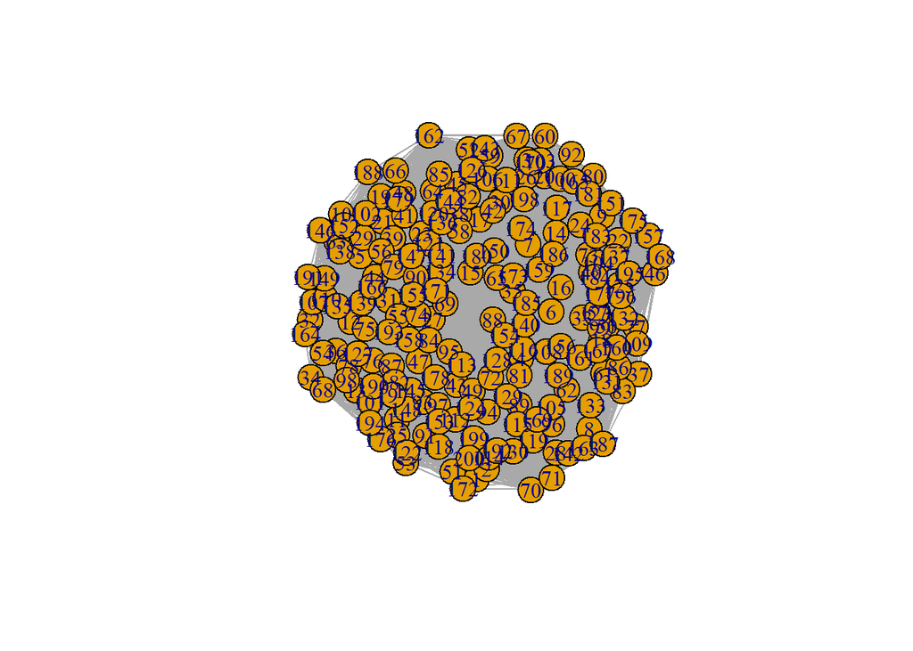

```r
g <-graph.adjacency(M, mode="undirected", weighted = TRUE)
plot (g)
```

Hacer la matariz en negariva para identificar valores maximos

```r
M <- -M
head(M[,1:6])
```

```
##            [,1]      [,2]       [,3]       [,4]      [,5]       [,6]
## [1,]   0.000000 -33.36635 -86.935517  -8.375608 -45.83037 -47.292127
## [2,]  -8.086913   0.00000 -11.605955 -39.091410 -82.15133 -61.126050
## [3,] -52.845448 -10.63509   0.000000 -22.700600 -10.02156  -5.516215
## [4,] -28.219008 -90.94124 -60.428810   0.000000 -89.40508 -11.161483
## [5,] -90.941054 -92.43655  -5.217044 -13.384132   0.00000 -89.480654
## [6,] -70.604329 -25.67740 -48.587643 -13.243930 -54.94695   0.000000
```

Visualizar matiz

```r
M
```

[output not shown]

[output cut: 7020 more lines]

Grafica nueva con matriz negativa, ver el espacio-producto, tecnológico

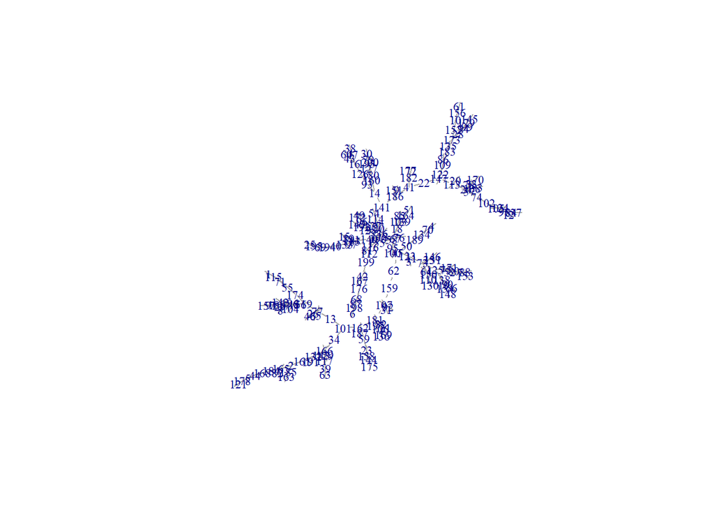

```r
g <-graph.adjacency(M, mode="undirected", weighted = TRUE)
MST<- minimum.spanning.tree(g)
plot(MST, vertex.shape="none", vertex.label.cex=.7)
```

Matriz de adyacencias (nuevo relacionamiento) Ver las aristas que hay entre los nodos

```r
A<- get.adjacency(MST, sparse = F)
```

```r
head(A)
```

[output not shown]

[output cut: 118 more lines]

Exportar nodos n-1 en gráfico gml

```r
write.graph(MST,file="g.gml", format = "gml")
```

Exportar resultados para cytoscape o gephi

```r
write.csv(A, file= "Adyacentes.csv")
```